# Lecture 07 - AutoRegressive Process

## Example: order selection

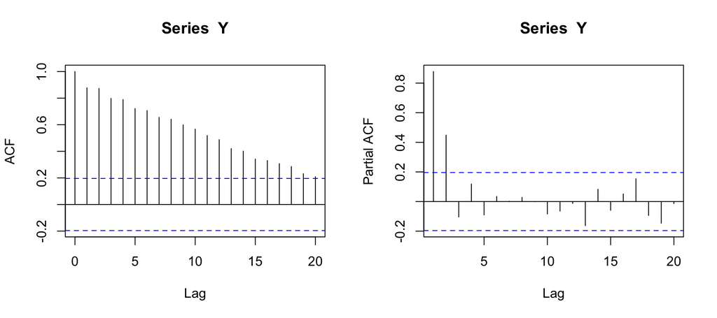

```r
  set.seed(4772)                        # you don't need to do this
  Y    <- arima.sim(list(ar = c(.6, .3) ), 100 ) + 8.5     # simulate AR(2)

  #- 1. ACF and PACF
  layout(matrix(1:2, 1, 2))             # two plots side by side
  acf(Y)                                # plot sample ACF of Y
  pacf(Y)                               # plot sample PACF of Y
```

```r
  layout(1)                             # return to 1 plot layout

  #- 2. AIC
  Fit8 <- ar(Y)                         # Fit AR(p). Find best p by AIC
  Fit8
```

```
##
## Call:
## ar(x = Y)
##
## Coefficients:
##      1       2
## 0.4842  0.4485
##
## Order selected 2  sigma^2 estimated as  0.8158
```

```r
  Fit8$aic                              # Lists AIC for each p (difference from the min value)
```

```
##           0           1           2           3           4           5
## 165.8366036  20.4616413   0.0000000   0.9041732   1.4922289   2.6672184
##           6           7           8           9          10          11
##   4.5483544   6.5481072   8.4675061  10.4673577  11.7533303  13.3400925
##          12          13          14          15          16          17
##  15.3250861  14.6416101  15.9542820  17.6016493  19.3383446  18.9289299
##          18          19          20
##  20.0358657  19.8630831  21.8436242
```

```r
  #- 3. Parameter Significance
  Fit8 <- ar(Y, aic=F, order.max=3 )    # fit AR(p). force p=3.

  Fit8$ar                               #- phi1 hat and phi2 hat
```

```
## [1]  0.5310328  0.4990773 -0.1043956
```

```r
  1.96*sqrt(Fit8$asy.var.coef)          #- standard error for phi hats
```

```
##           [,1]     [,2]      [,3]
## [1,] 0.1989486      NaN       NaN
## [2,]       NaN 0.202232       NaN
## [3,]       NaN      NaN 0.1989486
```

## Example: AIC Simulation Study

If we use AIC all the time, what is the probability we end up with correct $p$?

- Set $p=2$. Generate simulated AR(2).
- Use **ar(Y)** and search for best $p$ by using Minimum AIC.
- Repeat 1000 times. How many time do we end up with right $p$?

```r
  #- Simulation Study of choosing p by AIC
  Result <- 0
  for (i in 1:1000){
    Y <- arima.sim(list(ar = c(.6, .3) ), 100 )
    Fit7 <- ar(Y)                         # find AR(p) by AIC
    # print(c(i, Fit7$order) )            # print order on screen (optional)
    Result[i] <- Fit7$order               # save value of p chosen
  }
  head(Result, 100)                       # first 100 p
```

```
##   [1] 1 2 2 3 1 2 2 3 3 3 5 2 2 2 2 2 3 3 2 8 5 4 2 2 2 2 2 2 2 2 1 1 2 1 6
##  [36] 2 2 1 2 6 2 2 2 2 1 2 2 2 1 2 3 2 1 2 6 2 2 2 1 2 2 2 2 2 2 2 3 1 5 2
##  [71] 5 2 2 2 2 2 2 3 2 2 2 2 2 2 2 2 1 2 2 1 2 2 2 1 2 7 4 4 4 2
```

```r
  mean(Result==2)                         # propotion of times p=2
```

```
## [1] 0.636
```

# 3. Residual Analysis of AR(p)

- After parameter estimation, say we have AR(2) model
  $$X_t = \hat \phi_1 X_{t-1} + \hat \phi_2 X_{t-2} + e_t.$$
- $X_t$ are observations. We never get to observe $e_t$.
- We must estimate $e_t$ by **residuals**.
  $$\hat e_t = X_t -\hat \phi_1 X_{t-1} -\hat \phi_2 X_{t-2}
  \hspace10mm t= 3,4,\ldots,n$$
- This is the reason, that for AR($p$), first $p$ residuals are NA.
- If the model chosen is fitting the data adequately, $\hat e_t$ should behave like $e_t$. i.e. residuals should behave like White Noise.
- Plot **ACF** and **PACF** of the residuals, and look for sign of non-WN.

## Example: Residual Analysis

```r
  Y <- arima.sim(list(ar = c(.6, .3) ), 100 )
  Fit9 <- ar(Y, aic=F, order.max=2, demean=F)    # force p=2
  Fit9$ar
```

```
## [1] 0.5247036 0.3170003
```

```r
  e.hat <- Fit9$resid                            # extract the residuals
  e.hat
```

```
## Time Series:
## Start = 1
## End = 100
## Frequency = 1
##   [1]          NA          NA -0.60325406  0.34269005  1.79632330
##   [6]  1.13778289 -0.80776111  0.74819334 -0.09194477  1.24787811
##  [11]  0.55052783  2.46390400 -1.06017315  0.36711027 -0.36164192
##  [16] -0.13665509 -1.23790852  2.15378496 -0.28462867  1.43360109
##  [21]  0.11385828  1.16795314  0.56267776  1.94067099 -1.55608941
##  [26] -0.58859579  0.75013604  1.03926326 -0.98778315  0.01377071
##  [31]  1.65786026 -0.32440689 -1.13863270  1.94563376 -0.50685346
##  [36]  0.65758852 -0.95320578 -2.15939633  0.38554627  1.93051726
##  [41] -1.49673802 -1.42776276 -0.04268779 -0.70885887  0.93801249
##  [46] -0.35612610 -0.05095193  0.51954845  0.61419757 -0.54879681
##  [51] -1.47400979  0.76926730  0.25814124 -0.26721191 -1.97821621
##  [56]  0.22996611 -1.37341098  0.82804953  0.62935166 -0.30776479
##  [61]  0.20708397 -0.66269705  1.59543797  0.08060321 -1.22220298
##  [66] -0.90546043  0.13375616  0.43098087  0.78200417  0.52699821
##  [71]  0.80252802  0.01635166 -0.23462215  0.93739407 -0.02001775
##  [76] -1.33858931  1.13487422  1.21799318  2.57819589  1.51864674
##  [81]  0.27964038 -0.07454466 -0.89719917  0.95920949 -1.49661280
##  [86]  0.41399264 -0.65889616 -2.27235624 -0.47636037 -0.12779601
##  [91] -1.65885127 -0.17436080 -0.62971285 -0.02530904 -1.93141265
##  [96]  0.74614290 -1.27317021 -0.61004752  0.74174500 -0.43970028
```

```r
  Y[3]-Fit9$ar[1]*Y[2] - Fit9$ar[2]*Y[1]
```

```
## [1] -0.6032541
```

# Example: Dow Jones 1972

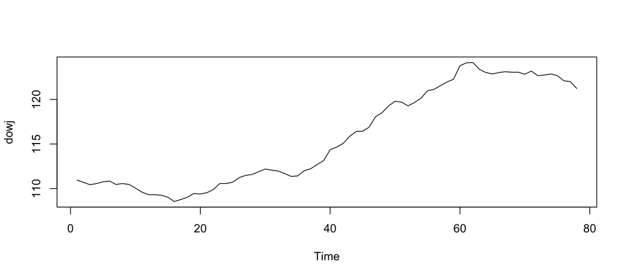

```r
  # read in daily Dow Jones data from my website
  D  <- read.csv("http://gozips.uakron.edu/~nmimoto/pages/datasets/dowj.csv")
  D1 <- ts(D, start=c(1,1), freq=1)   # turn the data into TS object
  plot(D1)
```

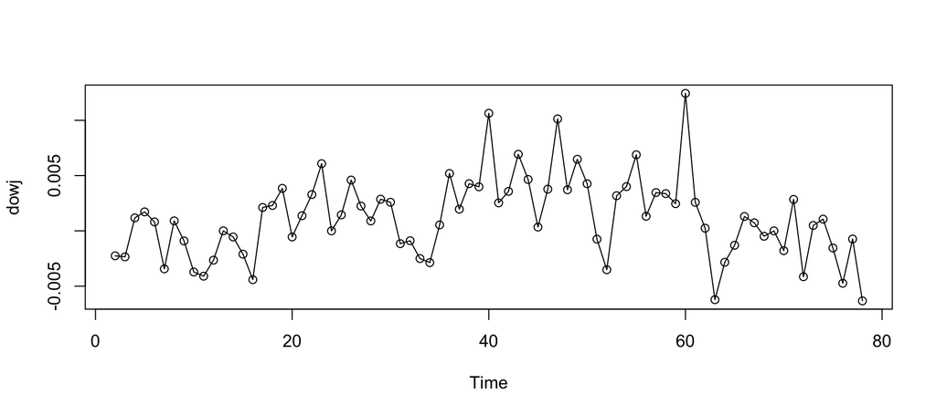

```r
  Y <- diff(log(D1))                  # Take log-difference
  plot(Y, type='o')
```

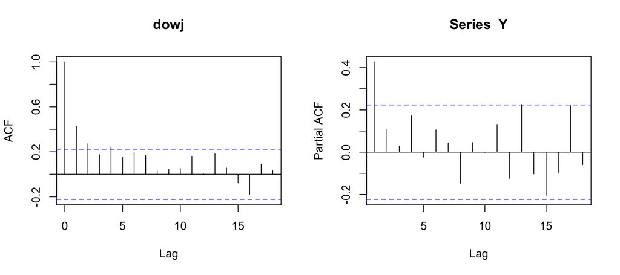

```r
  layout(matrix(1:2, 1,2))            # 2 plots side by side
  acf(Y)
  pacf(Y)
```

```r
  layout(1)                           # reset the layout

  Fit11 <- ar(Y)      # Fit AR(p) default use Y-W for estimator,
                      # and AIC to look for best p. demean=TRUE is also default
  Fit12 <- ar(Y, aic=TRUE,  order.max=20)    # best p is chosen by aic (same as above)

  Fit11                                      # see the summary of fit
```

```
##
## Call:
## ar(x = Y)
##
## Coefficients:
##      1
## 0.4274
##
## Order selected 1  sigma^2 estimated as  1.098e-05
```

```r
  sqrt( Fit11$asy.var.coef )                 # SE of the estimator
```

```
##           [,1]
## [1,] 0.1043933
```

```r
  Fit13 <- ar(Y, aic=FALSE,  order.max=2)    # force fit AR(2)
  Fit13
```

```
##
## Call:
## ar(x = Y, aic = FALSE, order.max = 2)
##
## Coefficients:
##      1       2
## 0.3808  0.1091
##
## Order selected 2  sigma^2 estimated as  1.099e-05
```

```r
  sqrt( Fit13$asy.var.coef )                 # SE of the estimator
```

```
##           [,1]      [,2]
## [1,] 0.1155538       NaN
## [2,]       NaN 0.1155538
```

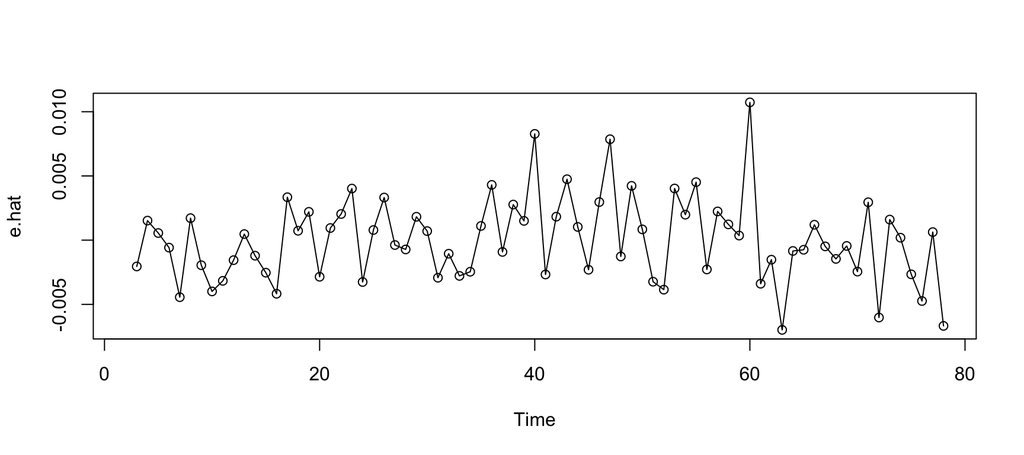

```r
  e.hat <- Fit11$resid                       # extract residuals from the 1st fit
  plot(e.hat, type="o")                      # plot residuals
```

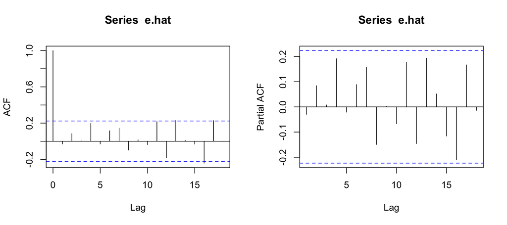

```r
  layout(matrix(1:2, 1,2))                   # 2 plots side by side
  acf(e.hat, na.action=na.pass)              # check for autocorrelation in residuals
  pacf(e.hat, na.action=na.pass)
```

```r
  layout(1)                                  # reset the layout
```

# Summary

- To fit AR(p), you must first decide to de-mean or not. It’s customary to just de-mean.  
  **ar()** does that by default.
- Look at sample ACF and sample PACF to guess p.
- Akaike Information Criteria can also be used to look for the best $p$. **ar()** function does that automatically by default. You want MINIMUM AIC.
- Check parameter significance of estimated parameters. If the last parameter is not significant, reduce $p$ by 1, and fit again.
- After getting the suggested “best” $p$ from AIC, fit model with p+1, and see if the last parameter estimate comes out non-significant.
- Check residuals for autocorrelation by plotting reiduals and plotting ACF and PACF.

# R-code only

Here’s all the R-code used in this page without any output:

```r
# 1. De-mean or not

  Y    <- arima.sim(list(ar = c(.6, .3) ), 100 )  + 8.5
  plot(Y, type="o")
  mean(Y)

  Fit3 <- ar(Y, aic=F, order.max=2)               # demean=TRUE is the default
  Fit4 <- ar(Y, aic=F, order.max=2, demean=TRUE)  # same as above
  Fit3
  Fit4

  Fit5 <- ar(Y, aic=F, order.max=2, demean=FALSE) # if you don't take the mean out
  Fit5                                            # you get different estimates

  Fit6 <- ar(Y-mean(Y), aic=F, order.max=2, demean=FALSE)  # same as demean=TRUE
  Fit6


# 2. Order Selection of AR(p)

## a. ACF and PACF

  set.seed(345)
  Y    <- arima.sim(list(ar = c(.6, .3) ), 100 )  + 8.5
  plot(Y, type="o")

  layout(matrix(1:2, 1, 2))  # two plots side by side
  acf(Y)                     # plot sample ACF of Y
  pacf(Y)                    # plot sample PACF of Y
  layout(1)                  # return to 1 plot layout


## Example: order selection

  set.seed(4772)                        # you don't need to do this
  Y    <- arima.sim(list(ar = c(.6, .3) ), 100 ) + 8.5     # simulate AR(2)

  #- 1. ACF and PACF
  layout(matrix(1:2, 1, 2))             # two plots side by side
  acf(Y)                                # plot sample ACF of Y
  pacf(Y)                               # plot sample PACF of Y
  layout(1)                             # return to 1 plot layout

  #- 2. AIC
  Fit8 <- ar(Y)                         # Fit AR(p). Find best p by AIC
  Fit8
  Fit8$aic                              # Lists AIC for each p (difference from the min value)

  #- 3. Parameter Significance
  Fit8 <- ar(Y, aic=F, order.max=3 )    # fit AR(p). force p=3.

  Fit8$ar                               #- phi1 hat and phi2 hat
  1.96*sqrt(Fit8$asy.var.coef)          #- standard error for phi hats



## Example:  AIC Simulation Study

  #- Simulation Study of choosing p by AIC
  Result <- 0
  for (i in 1:1000){
    Y <- arima.sim(list(ar = c(.6, .3) ), 100 )
    Fit7 <- ar(Y)                         # find AR(p) by AIC
    # print(c(i, Fit7$order) )            # print order on screen (optional)
    Result[i] <- Fit7$order               # save value of p chosen
  }
  head(Result, 100)                       # first 100 p
  mean(Result==2)                         # propotion of times p=2


## Example: Residual Analysis

  Y <- arima.sim(list(ar = c(.6, .3) ), 100 )
  Fit9 <- ar(Y, aic=F, order.max=2, demean=F)    # force p=2
  Fit9$ar
  e.hat <- Fit9$resid                            # extract the residuals
  e.hat

  Y[3]-Fit9$ar[1]*Y[2] - Fit9$ar[2]*Y[1]

# Example: Dow Jones 1972

  # read in daily Dow Jones data from my website
  D  <- read.csv("http://gozips.uakron.edu/~nmimoto/pages/datasets/dowj.csv")
  D1 <- ts(D, start=c(1,1), freq=1)   # turn the data into TS object
  plot(D1)

  Y <- diff(log(D1))                  # Take log-difference
  plot(Y, type='o')
  layout(matrix(1:2, 1,2))            # 2 plots side by side
  acf(Y)
  pacf(Y)
  layout(1)                           # reset the layout

  Fit11 <- ar(Y)      # Fit AR(p) default use Y-W for estimator,
                      # and AIC to look for best p. demean=TRUE is also default
  Fit12 <- ar(Y, aic=TRUE,  order.max=20)    # best p is chosen by aic (same as above)

  Fit11                                      # see the summary of fit
  sqrt( Fit11$asy.var.coef )                 # SE of the estimator


  Fit13 <- ar(Y, aic=FALSE,  order.max=2)    # force fit AR(2)
  Fit13
  sqrt( Fit13$asy.var.coef )                 # SE of the estimator

  e.hat <- Fit11$resid                       # extract residuals from the 1st fit
  plot(e.hat, type="o")                      # plot residuals
  layout(matrix(1:2, 1,2))                   # 2 plots side by side
  acf(e.hat, na.action=na.pass)              # check for autocorrelation in residuals
  pacf(e.hat, na.action=na.pass)
  layout(1)                                  # reset the layout
```